# Analyst Intern, Data Science & Solutions Project

Carson Batchelor

09/01/23

# Introduction

The purpose of this project is to gauge your technical skills and problem solving ability by working through something similar to a real NBA data science project. You will work your way through this R Markdown document, answering questions as you go along. Please begin by adding your name to the “author” key in the YAML header. When you’re finished with the document, come back and type your answers into the answer key at the top. Please leave all your work below and have your answers where indicated below as well. Please note that we will be reviewing your code so make it clear, concise and avoid long printouts. Feel free to add in as many new code chunks as you’d like.

Remember that we will be grading the quality of your code and visuals alongside the correctness of your answers. Please try to use the tidyverse as much as possible (instead of base R and explicit loops.)

**Note:**

**Throughout this document, any `season` column represents the year each season started. For example, the 2015-16 season will be in the dataset as 2015. For most of the rest of the project, we will refer to a season by just this number (e.g. 2015) instead of the full text (e.g. 2015-16).**

# Answers

## Part 1

**Question 1:**

- 1st Team: 19.4 points per game
- 2nd Team: 18.6 points per game
- 3rd Team: 16.9 points per game
- All-Star: 16.3 points per game

**Question 2:** 3.7 Years

**Question 3:**

- Elite: 4 players.
- All-Star: 0 players.
- Starter: 10 players.
- Rotation: 6 players.
- Roster: 10 players.
- Out of League: 43 players.

**Open Ended Modeling Question:** Please show your work and leave all responses below in the document.

## Part 2

**Question 1:** 28.9%  
**Question 2:** Written question, put answer below in the document.  
**Question 3:** Written question, put answer below in the document.

# Setup and Data

```r
library(tidyverse)
# Note, you will likely have to change these paths. If your data is in the same folder as this project,
# the paths will likely be fixed for you by deleting ../../Data/awards_project/ from each string.
awards <- read_csv("awards_data.csv")
player_data <- read_csv("player_stats.csv")
team_data <- read_csv("team_stats.csv")
rebounding_data <- read_csv("team_rebounding_data_22.csv")
```

## Part 1 – Awards

In this section, you’re going to work with data relating to player awards and statistics. You’ll start with some data manipulation questions and work towards building a model to predict broad levels of career success.

### Question 1

**QUESTION:** What is the average number of points per game for players in the 2007-2021 seasons who won All NBA First, Second, and Third teams (**not** the All Defensive Teams), as well as for players who were in the All-Star Game (**not** the rookie all-star game)?

```r
# Here and for all future questions, feel free to add as many code chunks as you like. Do NOT put echo = F though, we'll want to see your code.

# Change the column names to format without spaces then create a list of the awards I need.
names(awards) = make.names(names(awards), unique=TRUE)
awards_list = c("All.NBA.First.Team", "All.NBA.Second.Team", "All.NBA.Third.Team", "all_star_game")
averages_list = c()

# For loop that goes through the desired awards and filters based on if players got that specific award.
for (award in awards_list) {
  player_ids = awards %>%
    filter(between(season, 2007, 2021),
           (!!as.name(award)) == 1) %>%
    pull(nbapersonid)

  # use the player ids from previous step to filter the player data data set then calculate the points per game.
  players_average_PPG = player_data %>%
    filter(nbapersonid %in% player_ids) %>%
    mutate(PPG = points/games) %>%
    summarise(avg_PPG = mean(PPG)) %>%
    pull(avg_PPG)

  # add the average points per game to a vector after each loop.
  averages_list = c(averages_list, players_average_PPG)
}

# create a data frame with these averages for a good visual and easier analysis.
average_PPG_df = data.frame(Awards = awards_list,
                Players_Average_PPG = averages_list)
```

**ANSWER 1:**

1st Team: 19.4 points per game  
2nd Team: 18.6 points per game  
3rd Team: 16.9 points per game  
All-Star: 16.3 points per game

### Question 2

**QUESTION:** What was the average number of years of experience in the league it takes for players to make their first All NBA Selection (1st, 2nd, or 3rd team)? Please limit your sample to players drafted in 2007 or later who did eventually go on to win at least one All NBA selection. For example:

- Luka Doncic is in the dataset as 2 years. He was drafted in 2018 and won his first All NBA award in 2019 (which was his second season).
- LeBron James is not in this dataset, as he was drafted prior to 2007.
- Lu Dort is not in this dataset, as he has not received any All NBA honors.

```r
# filter out players drafted before 2007.
post_2007_ids = player_data %>%
  filter(draftyear >= 2007) %>%
  pull(nbapersonid)

# find the player ids and season of the first year these players earned one of the All NBA awards. I included the All NBA Defensive awards because I thought it would be a notable addition and it does not specify otherwise like the previous question.
award_selection = awards %>%
  filter(nbapersonid %in% post_2007_ids,
         (All.NBA.First.Team == 1 |
          All.NBA.Second.Team == 1 |
          All.NBA.Third.Team == 1 |
          All.NBA.Defensive.First.Team == 1 |
          All.NBA.Defensive.Second.Team == 1)) %>%
  distinct(nbapersonid, .keep_all = TRUE) %>%
  select(nbapersonid, season)

# use the player ids from the previous step to find the draft years of each of these players.
draft_years = player_data %>%
  filter(nbapersonid %in% award_selection$nbapersonid) %>%
  distinct(nbapersonid, .keep_all = TRUE) %>%
  select(nbapersonid, player, draftyear)

# combine the two data frames then calculate the difference between a players draft year and the first year they received an award.
combined_df = merge(award_selection, draft_years) %>%
  mutate(experience = season - draftyear)

# find the average years of experience of all the selected players.
years_before_award = mean(combined_df$experience)
```

**ANSWER 2:**

3.7 Years

## Data Cleaning Interlude

You’re going to work to create a dataset with a “career outcome” for each player, representing the highest level of success that the player achieved for **at least two** seasons *after his first four seasons in the league* (examples to follow below!). To do this, you’ll start with single season level outcomes. On a single season level, the outcomes are:

- Elite: A player is “Elite” in a season if he won any All NBA award (1st, 2nd, or 3rd team), MVP, or DPOY in that season.
- All-Star: A player is “All-Star” in a season if he was selected to be an All-Star that season.
- Starter: A player is a “Starter” in a season if he started in at least 41 games in the season OR if he played at least 2000 minutes in the season.
- Rotation: A player is a “Rotation” player in a season if he played at least 1000 minutes in the season.
- Roster: A player is a “Roster” player in a season if he played at least 1 minute for an NBA team but did not meet any of the above criteria.
- Out of the League: A player is “Out of the League” if he is not in the NBA in that season.

We need to make an adjustment for determining Starter/Rotation qualifications for a few seasons that didn’t have 82 games per team. Assume that there were 66 possible games in the 2011 lockout season and 72 possible games in each of the 2019 and 2020 seasons that were shortened due to covid. Specifically, if a player played 900 minutes in 2011, he **would** meet the rotation criteria because his final minutes would be considered to be 900 * (82/66) = 1118. Please use this math for both minutes and games started, so a player who started 38 games in 2019 or 2020 would be considered to have started 38 * (82/72) = 43 games, and thus would qualify for starting 41. Any answers should be calculated assuming you round the multiplied values to the nearest whole number.

Note that on a season level, a player’s outcome is the highest level of success he qualifies for in that season. Thus, since Shai Gilgeous-Alexander was both All-NBA 1st team and an All-Star last year, he would be considered to be “Elite” for the 2022 season, but would still qualify for a career outcome of All-Star if in the rest of his career he made one more All-Star game but no more All-NBA teams. Note this is a hypothetical, and Shai has not yet played enough to have a career outcome.

Examples:

- A player who enters the league as a rookie and has season outcomes of Roster (1), Rotation (2), Rotation (3), Roster (4), Roster (5), Out of the League (6+) would be considered “Out of the League,” because after his first four seasons, he only has a single Roster year, which does not qualify him for any success outcome.
- A player who enters the league as a rookie and has season outcomes of Roster (1), Rotation (2), Starter (3), Starter (4), Starter (5), Starter (6), All-Star (7), Elite (8), Starter (9) would be considered “All-Star,” because he had at least two seasons after his first four at all-star level of production or higher.
- A player who enters the league as a rookie and has season outcomes of Roster (1), Rotation (2), Starter (3), Starter (4), Starter (5), Starter (6), Rotation (7), Rotation (8), Roster (9) would be considered a “Starter” because he has two seasons after his first four at a starter level of production.

### Question 3

**QUESTION:** There are 73 players in the `player_data` dataset who have 2010 listed as their draft year. How many of those players have a **career** outcome in each of the 6 buckets?

```r
# Create a data set that joins all the player data with their award data.

all_data = left_join(player_data, awards, by = c("nbapersonid", "season")) %>%
  # add rows for the adjusted minutes and games started in the shortened 2011 and covid seasons.
  mutate(PPG = points/games,
         adj_mins_2011 = ifelse(season == 2011,
                              (mins * (82/66)),NA_real_),
         adj_starts_2011 = ifelse(season == 2011,
                             (games_start * (82/66)), NA_real_),
         adj_mins_covid = ifelse(season %in% c(2019,2020),
                              (mins * (82/72)), NA_real_),
         adj_starts_covid = ifelse(season %in% c(2019,2020),
                        (games_start * (82/72)), NA_real_),
         # Put a 6 in the Elite column if the player had Elite Player Status
         Elite = ifelse((All.NBA.First.Team == 1 |
          All.NBA.Second.Team == 1 |
          All.NBA.Third.Team == 1 |
          All.NBA.Defensive.First.Team == 1 |
          All.NBA.Defensive.Second.Team == 1 |
          Most.Valuable.Player_rk == 1 |
          Defensive.Player.Of.The.Year_rk == 1), 6, 0),

         # Put a 5 in the Allstar column if the player had All star player Status
         Allstar = ifelse(all_star_game == TRUE, 5, 0),

         # Put a 4 in the Starter column if the player had Starter player Status
         Starter = ifelse((games_start >= 41 |
                           adj_starts_2011 >= 41 |
                           adj_starts_covid >= 41 |
                           mins >= 2000 |
                           adj_mins_2011 >= 2000 |
                           adj_mins_covid >= 2000), 4, 0),
         # Put a 3 in the Rotations column if the player had Rotation player Status
         Rotation = ifelse(mins >= 1000 |
                            adj_mins_2011 >= 1000 |
                            adj_mins_covid >= 1000, 3, 0),
         # Put a 2 in th Roster Column if the the player had Roster player status
         Roster = ifelse(mins >= 1, 2, 0)) %>%
  # Count the total number of seasons each player was in
  group_by(nbapersonid) %>%
  distinct(season, .keep_all = TRUE) %>%
  mutate(num_seasons = n())

out_names = c('Elite', 'Allstar', 'Starter', 'Rotation', 'Roster')
#add new column that contains the max value in each row
all_data$outcome = apply(all_data[out_names], 1, max, na.rm=TRUE)
all_data[is.na(all_data)] = 0

# Use only the players drafted in 2010
drafted_2010 = all_data %>%
  filter(draftyear == 2010) %>%
  filter(num_seasons > 5)

category_mapping <- c('2' = "Roster", '3' = "Rotation", '4' = "Starter", '5' = "Allstar", '6' = "Elite")

#create a final data set that adds up the total number of players in each bucket
final_outcomes <- drafted_2010 %>%
  filter(season >= 2014) %>%
  group_by(nbapersonid) %>%
  count(outcome) %>%
  # look at only the outcomes that the player had 2 or more years
  filter(n >= 2) %>%
  summarise(best_outcome = max(outcome)) %>%
  ungroup() %>%
  group_by(best_outcome) %>%
  summarise(total = n()) %>%
  mutate(best_outcome = case_when(
    best_outcome %in% names(category_mapping) ~ category_mapping[as.character(best_outcome)],
    TRUE ~ as.character(best_outcome)))
```

**ANSWER 3:**

Elite: 4 players.  
All-Star: 0 players.  
Starter: 10 players.  
Rotation: 6 players.  
Roster: 10 players.  
Out of League: 43 players.

### Open Ended Modeling Question

In this question, you will work to build a model to predict a player’s career outcome based on information up through the first four years of his career.

This question is intentionally left fairly open ended, but here are some notes and specifications.

1. We know modeling questions can take a long time, and that qualified candidates will have different levels of experience with “formal” modeling. Don’t be discouraged. It’s not our intention to make you spend excessive time here. If you get your model to a good spot but think you could do better by spending a lot more time, you can just write a bit about your ideas for future improvement and leave it there. Further, we’re more interested in your thought process and critical thinking than we are in specific modeling techniques. Using smart features is more important than using fancy mathematical machinery, and a successful candidate could use a simple regression approach.
2. You may use any data provided in this project, but please do not bring in any external sources of data. Note that while most of the data provided goes back to 2007, All NBA and All Rookie team voting is only included back to 2011.
3. A player needs to complete at least three additional seasons after their first four to be considered as having a distinct career outcome for our dataset. (We are using 3+ instead of 2+ just to give each player a little more time to accumulate high level seasons before we classify his career). Because the dataset in this project ends in 2021, this means that a player would need to have had the chance to play in the ’21, ’20, and ’19 seasons after his first four years, and thus his first four years would have been ’18, ’17, ’16, and ’15. **For this reason, limit your training data to players who were drafted in or before the 2015 season.** Karl-Anthony Towns was the #1 pick in that season.
4. Once you build your model, predict on all players who were drafted in 2018-2021 (They have between 1 and 4 seasons of data available and have not yet started accumulating seasons that inform their career outcome).
5. You can predict a single career outcome for each player, but it’s better if you can predict the probability that each player falls into each outcome bucket.
6. Include, as part of your answer:
- A brief written overview of how your model works, targeted towards a decision maker in the front office without a strong statistical background.
- What you view as the strengths and weaknesses of your model.
- How you’d address the weaknesses if you had more time and or more data.
- A ggplot or ggplotly visualization highlighting some part of your modeling process, the model itself, or your results.
- Your predictions for Shai Gilgeous-Alexander, Zion Williamson, James Wiseman, and Josh Giddey.
- (Bonus!) An html table (for example, see the package `reactable`) containing all predictions for the players drafted in 2019-2021.

```r
library(ggplot2)
library(nnet)
# Change the number value categories to the actual names of the outcomes.
category_mapping <- c('2' = "Roster", '3' = "Rotation", '4' = "Starter", '5' = "Allstar", '6' = "Elite")
all_data <- all_data %>%
  mutate(outcome = case_when(
    outcome %in% names(category_mapping) ~ category_mapping[as.character(outcome)],
    TRUE ~ as.character(outcome)))

# Create a training set of players drafted before 2016 and a Test set of players drafted between 2018 and 2021.
train_data = all_data %>%
  filter(draftyear <= 2015)
test_data = all_data %>%
  filter(draftyear >= 2018 && draftyear <= 2021)

# Get rid of the scientific notation for easier analysis
options(scipen = 100, digits = 4)

# Fit a multinomial logistic regression model
model = multinom(outcome ~ PPG + mins + VORP, data = train_data)
# Summarize the model
sum = summary(model)

# Create a new data frame with predictor variables
new_data = data.frame(PPG = test_data$PPG, mins = test_data$mins, test_data$VORP)
# predict the probaility of each category for the test dataset with the model
predicted_probs = data.frame(player = test_data$player,
                              season = test_data$season, round(predict(model, newdata = test_data, type = "probs"), digits = 8))


# Summarize the data for the selected players in order to find the probabilty that the player has a career outcome in each category instead of just a season outcome.
pred_players = c("Shai Gilgeous-Alexander", "Zion Williamson", "James Wiseman", "Josh Giddey")
career_outcome_probs = predicted_probs %>%
  filter(player %in% pred_players) %>%
  group_by(player) %>%
  mutate(num_seasons = n()) %>%
  # Calculate the average probability over all of a players season for their career outcome.
  summarize(Elite = sum(Elite) / num_seasons,
         Allstar = sum(Allstar) / num_seasons,
         Starter = sum(Starter) / num_seasons,
         Rotation = sum(Rotation) / num_seasons,
         Roster = sum(Roster) / num_seasons) %>%
  distinct(player, .keep_all = TRUE) %>%
  pivot_longer(cols = all_of(out_names), names_to = "Category", values_to = "Probability")
```

## Table containing all predictions for the players drafted in 2019-2021.

```r
library(reactable)
#Create An html table containing all predictions for the players drafted in 2019-2021.
bonus_set = all_data %>%
  filter(draftyear >= 2019 && draftyear <= 2021)
# Create a new data frame with predictor variables
new_data = data.frame(PPG = bonus_set$PPG, mins = bonus_set$mins, bonus_set$VORP)
# predict the probability of each category for the bonus dataset with the model
predicted_probs = data.frame(player = bonus_set$player,
                              season = bonus_set$season, round(predict(model, newdata = bonus_set, type = "probs"), digits = 8))

bonus_outcome_probs = predicted_probs %>%
  group_by(player) %>%
  mutate(num_seasons = n()) %>%
  # Calculate the average probability over all of a players season for their career outcome.
  summarize(Elite = sum(Elite) / num_seasons,
         Allstar = sum(Allstar) / num_seasons,
         Starter = sum(Starter) / num_seasons,
         Rotation = sum(Rotation) / num_seasons,
         Roster = sum(Roster) / num_seasons) %>%
  distinct(player, .keep_all = TRUE)
# Create the HTML table using reactable with named column definitions
html_table <- reactable(
  data = bonus_outcome_probs,
  columns = list(
    player = colDef(name = "player"),
    Elite = colDef(name = "Elite"),
    Allstar = colDef(name = "Allstar"),
    Starter = colDef(name = "Starter"),
    Rotation = colDef(name = "Rotation"),
    Roster = colDef(name = "Roster")
  ),
  defaultColDef = colDef(
    align = "center"  # Center-align all columns
  )
)
# Print the HTML table
html_table
```

| player | Elite | Allstar | Starter | Rotation | Roster |
| --- | --- | --- | --- | --- | --- |
| Aaron Henry | 0 | 0 | 0 | 1e-08 | 0.99999999 |
| Aaron Nesmith | 9e-08 | 1.45e-07 | 1.7935e-05 | 0.00191902 | 0.998062805 |
| Aaron Wiggins | 0.00020313 | 0.00069251 | 0.10716783 | 0.88316607 | 0.00877046 |
| Adam Mokoka | 0 | 0 | 0 | 6e-08 | 0.99999994 |
| Ade Murkey | 0 | 0 | 0 | 1e-08 | 0.99999999 |
| Admiral Schofield | 0 | 0 | 1.65e-07 | 4.343e-05 | 0.999956405 |
| Ahmad Caver | 0 | 0 | 0 | 1e-08 | 0.99999999 |
| Aleem Ford | 0 | 0 | 0 | 4e-08 | 0.99999996 |
| Aleksej Pokusevski | 0.000254355 | 0.00062382 | 0.08757736 | 0.869644025 | 0.04190043 |
| Alen Smailagic | 0 | 0 | 0 | 1.05e-07 | 0.999999895 |

[output cut: 284 more lines]

## Overview of the Model:

This model is designed to help analyst predict a player’s career outcome based on their statistics. The goal is to see whether a player is the most likely to become an “Elite” player, an “Allstar,” a “Starter,” a “Rotation” player, or simply remain on the “Roster.” These outcomes are predicted based on certain stats such as Points Per Game (PPG), minutes played (mins), and Value Over Replacement Player (VORP).

## How the Model Works:

- The model begins with changing numerical category values to more meaningful outcome names (for example, “2” is “Roster”). The data is split into a training set containing player who were drafted before 2016 and a test set containing data from players drafted between 2018 and 2021.
- Multinomial Logistic Regression: The actual model is a multinomial logistic regression. It uses the predictor variables (PPG, mins, and VORP) to predict the player’s career outcome category. The model learns the relationships between the statistics and the player outcomes when it is made on the training set.
- Predictions: Using the trained model, predictions are made for specific players (Shai Gilgeous-Alexander, Zion Williamson, James Wiseman, and Josh Giddey) based on their statistics in the test data set. A new data set is created that has each of these players and over all the season they play in, calculate the average probability they are in each category.

## Strengths of the Model:

- The model uses easily understood statistics to make predictions about player career outcomes, making it accessible to people with less statistical knowledge.
- It is very flexible and can be used with any additional features or data sources in the future, which can enhance prediction accuracy.
- The visualization makes it easy to understand and compare the career outcome probabilities for different players.

## Weaknesses of the Model:

- This model’s predictions are based on just player statistics, so it may not capture intangible factors like injuries, if there was anything that caused a player to not be able to play such as a suspension in a career, or changes in playing style that can significantly impact a player’s career.
- There could have been some analysis and comparison to how a player being a a team has impacted the overall teams stats.
- The model only considers data up to 2015 for training and data from 2018 to 2021 for testing so it is limited.

## Addressing Weaknesses:

- add More Features: I could Include additional features such as injury history, team performance, or player behavior to see more of the reason the statistics are the way they are.
- Extend the test period to include more recent data so that the players we are predicting have more data.
- regularly update the model with new data to account for changes in a players activity.

## Visualization:

The provided ggplot visualization shows the career outcome probabilities for the selected players.

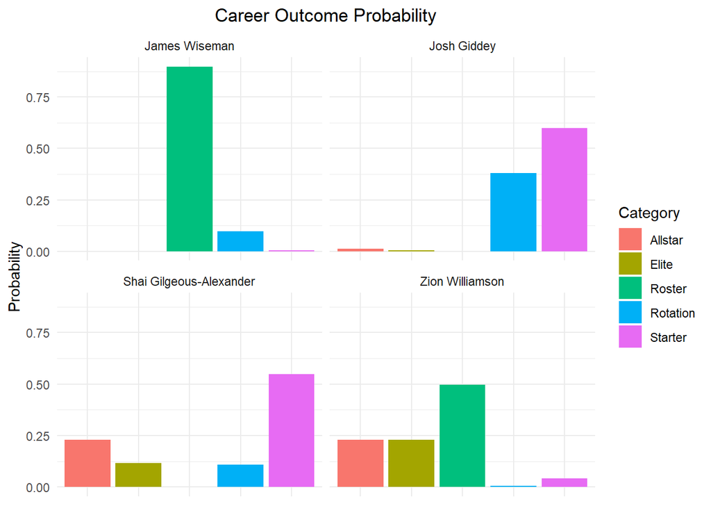

```r
# Create a bar graph that creates a graph for each of the selected player and has a seperate bar for each outcomes probability.
ggplot(career_outcome_probs, aes(x = Category, y = Probability, fill = Category))+
  geom_bar(stat = "identity", position = "dodge") +
  facet_wrap(~player) +
  theme_minimal() +
  theme(axis.text.x=element_blank(),
        axis.title.x=element_blank(),
        plot.title = element_text(hjust = 0.5)) +
  ggtitle("Career Outcome Probability")
```

## Predictions for Selected Players:

- Shai Gilgeous-Alexander: The model predicts having a career outcome as a “Starter” player.
- Zion Williamson: The model predicts the highest probability of being a “Roster” player, but I believe this may not be the most accurate because of his injury history so “Elite” or “Allstar” player may reflect his performance as a healthy player.
- James Wiseman: The model predicts a high probability of being a “Roster” player because of limited playing time.
- Josh Giddey: The model predicts Josh being a “Starter” player

## Part 2 – Predicting Team Stats

In this section, we’re going to introduce a simple way to predict team offensive rebound percent in the next game and then discuss ways to improve those predictions.

### Question 1

Using the `rebounding_data` dataset, we’ll predict a team’s next game’s offensive rebounding percent to be their average offensive rebounding percent in all prior games. On a single game level, offensive rebounding percent is the number of offensive rebounds divided by their number offensive rebound “chances” (essentially the team’s missed shots). On a multi-game sample, it should be the total number of offensive rebounds divided by the total number of offensive rebound chances.

Please calculate what OKC’s predicted offensive rebound percent is for game 81 in the data. That is, use games 1-80 to predict game 81.

```r
# look at all the games before the game being predicted and find the average offensive rebound percent
predicted_game = 81
OKC_reb = rebounding_data %>%
  filter(team == "OKC", game_number < predicted_game) %>%
  summarise(average_off_reb = sum(offensive_rebounds) / sum(off_rebound_chances))
```

**ANSWER 1:**

28.9%

### Question 2

There are a few limitations to the method we used above. For example, if a team has a great offensive rebounder who has played in most games this season but will be out due to an injury for the next game, we might reasonably predict a lower team offensive rebound percent for the next game.

Please discuss how you would think about changing our original model to better account for missing players. You do not have to write any code or implement any changes, and you can assume you have access to any reasonable data that isn’t provided in this project. Try to be clear and concise with your answer.

**ANSWER 2:**

I think using player-specific data in the model like using player statistics related to offensive rebounding ability, such as a player’s offensive rebounding percentage, number of offensive rebounds per game. Then if we consider which players will be in the game, we could have a more accurate prediction. I also think that using some form of the opponent’s defensive rebounding data such as If they are a strong defensive rebounding team that would affect how many offensive rebounds a team could get. using more opponent-specific data could help with these predictions.

### Question 3

In question 2, you saw and discussed how to deal with one weakness of the model. For this question, please write about 1-3 other potential weaknesses of the simple average model you made in question 1 and discuss how you would deal with each of them. You may either explain a weakness and discuss how you’d fix that weakness, then move onto the next issue, or you can start by explaining multiple weaknesses with the original approach and discuss one overall modeling methodology you’d use that gets around most or all of them. Again, you do not need to write any code or implement any changes, and you can assume you have access to any reasonable data that isn’t provided in this project. Try to be clear and concise with your answer.

**ANSWER 3:**

One weakness is that there is no analysis of the Long-Term Trends over the course of a season, a team could have picked up or traded for a great rebounded, or changed coaching/playing style, and just had a lot of growth as a team. The simple average model assumes a static team throughout the season. I think that this could be solved by implementing a season-long trend analysis. By looking at team performance over the entire season you will find changes in offensive rebounding to help adjust predictions based growth or decline in a teams performance.

This was kind of brought up in previous statement but average model assumes that a team’s offensive rebounding performance does not change over time. However, offensive rebounding can change a lot from game to game due to factors like opponent strength, game strategy, and players abilities. I think To address this, we can use a moving average approach by calculate a rolling average over a specific number of recent games. This approach would find the short-term trends in offensive rebounding performance in order to predict the next game.

Not only can a teams lineups be affected due to injuries, a player might not be playing because of a coaching decision, or a player needing rest. The model does not account for changes in player rotations. This could be solved by adding player rotation data into the model. By using which players are actually on the court in each game and what their offensive rebounding tendencies are, we could adjust the predictions based on the what the specific lineup is for the upcoming game.